# Research Questions

First thing's first, let's get a general overview of our store owners and their eCommerce businesses.

```python
def myround(x, base=100000):
    return int(base * round(float(x)/base))

print('Our respondents are on average {1:.0f} years old, have been invovled in eCommerce for {0:.1f} years,\
 and their median store revenue for last year was ${2:.0f} USD'.format(
modified_results['How many years have you been involved in eCommerce?'].mean(),
modified_results['How old are you?'].mean(),
myround(modified_results['What are the annual revenues of your business?'].median())
))
print('')
```

```
Our respondents are on average 39 years old, have been invovled in eCommerce for 6.5 years, and their median store revenue for last year was $800000 USD
```

Now, let's take a look at each different business type and see how they differ.

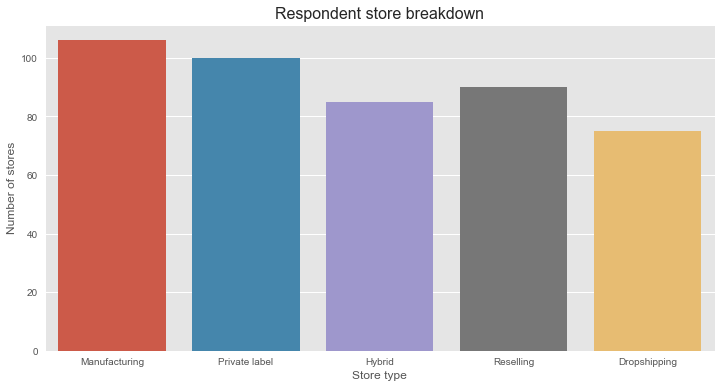

```python
fig, ax = plt.subplots(figsize=(12,6))
order = ['Manufacturing','Private label','Hybrid','Reselling','Dropshipping']
ax = sns.countplot(ax=ax, data=modified_results, x='Which model best describes your store type?', order=order)
plt.ylabel('Number of stores')
plt.xlabel('Store type')
plt.title('Respondent store breakdown', fontsize=16)
plt.tight_layout
plt.savefig('store_breakdown')
```

We have a pretty even split across each business model. First, let's compare each model on who their owners are. 95% confidence intervals are shown.

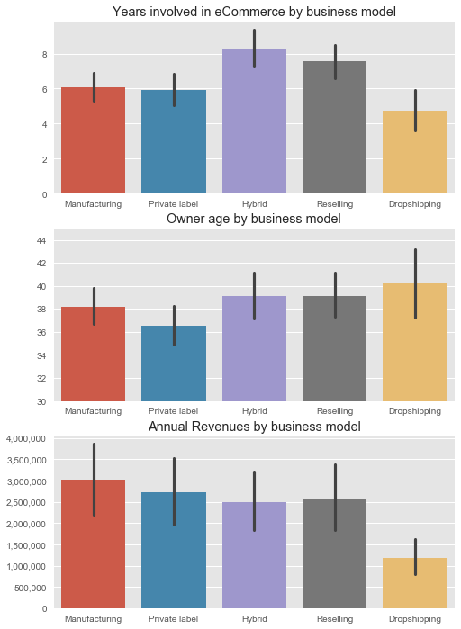

```python
import matplotlib.gridspec as gridspec
import matplotlib.ticker as ticker

#Create 2x2 subplots
gs = gridspec.GridSpec(3,1)

plt.figure(figsize=(8,12))
ax = plt.subplot(gs[0,0])
order = ['Manufacturing','Private label','Hybrid','Reselling','Dropshipping']
ax = sns.barplot(ax=ax, data=modified_results, x='Which model best describes your store type?', y='How many years have you been involved in eCommerce?', order=order)
plt.title('Years involved in eCommerce by business model')
plt.ylabel('')
plt.xlabel('')

ax = plt.subplot(gs[1,0])
ax = sns.barplot(ax=ax, data=modified_results, x='Which model best describes your store type?', y='How old are you?', order=order)
ax.set_ylim(30,45)
plt.title('Owner age by business model')
plt.ylabel('')
plt.xlabel('')

ax = plt.subplot(gs[2,0])
ax = sns.barplot(ax=ax, data=modified_results, x='Which model best describes your store type?', y='What are the annual revenues of your business?', order=order)
ax.get_yaxis().set_major_formatter(
    ticker.FuncFormatter(lambda x, p: format(int(x), ',')))
plt.title('Annual Revenues by business model')
plt.ylabel('')
plt.xlabel('')
plt.savefig('general_breakdown.png')
```

Drop-shipping has become increasingly popular over the past few years, and I expected drop-shippers to be younger and have less experience than the more traditional manufacturing model. Interestingly, we see that while drop-shippers tend to have less experience than owners of manufacturing businesses, the average age actually tends to be higher. Having said that, drop-shipping does have the greatest spread of owner ages, suggesting that it does have a lower barrier to entry and is easier for anyone to get involved with.

**One important number to take note of is the annual revenues by business model. Our drop-shippers in this survey average 2-2.5 times less revenue than other models, and this will be important to keep in mind when we start to look at some of the other statistics (such as total number of employees/contractors) in the next tables**

Below are two tables which compare all models across all numeric factors. Before, diving in, there are couple things to note:

1. To enable calculation of mean statistics and correlations between variables, many of the responses have been converted from a range to a single number (eg, 5-10 employees becomes 7.5). In most cases I've taken the mid-point of each range, although I've adjusted this where a distribution is heavily skewed in one direction or where there is no upper limit on the final range.
2. Keep in mind that for some of the variables (such as number of SKUs), the distribution of values is very skewed towards the tail (eg a small number of stores with 25,000 SKUs) and this disproportionately increases the average.

With that said, let's check out the top-level averages across groups

```python
modified_results.groupby('Which model best describes your store type?').apply(np.mean).iloc[:,0:17]
```

| Which model best describes your store type? | How many years have you been involved in eCommerce? | Excluding yourself, how many payrolled employees do you have? | How many contractors do you use in your business? | How many different SKUs do you sell? | How old are you? | How much do you struggle maintaining a work/life balance? | How many hours per week do you work? | Does your business provide a full-time income? Or, if you’re still working a job, could it? | What are the annual revenues of your business? | What is your average order value (AOV)? Please enter WITHOUT a "$" or currency sign. | Approximately how much did your revenue grow or shrink over the last year? | Approximately how much did your net income grow or shrink over the last year? | How much of an annual salary do you pay yourself? (A regular, recurring salary -- not business withdrawls or dividends) | What is your company’s approximate gross profit margin? (After paying product costs, but before fixed expenses.) | What is your company's approximate net profit margin? (Profits after paying all expenses and salaries, including your salary). | How much non-mortgage business related debt do you have? | How much cash in terms of your ongoing business expenses do you keep in your business? |
| --- | --- | --- | --- | --- | --- | --- | --- | --- | --- | --- | --- | --- | --- | --- | --- | --- | --- |
| Dropshipping | 4.720000 | 2.113333 | 3.573333 | 6343.933333 | 40.233333 | 5.880000 | 43.493333 | 0.733333 | 1.177333e+06 | 405.440000 | 1.440000 | 1.427333 | 31326.666667 | 0.281667 | 0.136333 | 38600.000000 | 3.686667 |
| Hybrid | 8.270588 | 6.358824 | 4.129412 | 4964.470588 | 39.147059 | 5.458824 | 49.994118 | 0.894118 | 2.502647e+06 | 176.494118 | 1.403529 | 1.348235 | 64094.117647 | 0.401765 | 0.167059 | 52294.117647 | 5.194118 |
| Manufacturing | 6.099057 | 6.429245 | 4.754717 | 1356.367925 | 38.212264 | 5.320755 | 48.051887 | 0.867925 | 3.020047e+06 | 129.273585 | 1.533019 | 1.490094 | 67698.113208 | 0.485142 | 0.201179 | 55613.207547 | 6.726415 |
| Private label | 5.915000 | 4.905000 | 3.890000 | 934.400000 | 36.520000 | 5.610000 | 44.295000 | 0.780000 | 2.721500e+06 | 124.880000 | 1.587000 | 1.538000 | 54065.000000 | 0.463500 | 0.208500 | 41975.000000 | 5.750000 |
| Reselling | 7.566667 | 5.316667 | 2.333333 | 5405.333333 | 39.111111 | 5.088889 | 45.627778 | 0.822222 | 2.566389e+06 | 771.444444 | 1.317222 | 1.290000 | 63122.222222 | 0.343611 | 0.134167 | 43583.333333 | 4.211111 |

```python
modified_results.groupby('Which model best describes your store type?').apply(np.mean).iloc[:,16:33]
```

| Which model best describes your store type? | How much cash in terms of your ongoing business expenses do you keep in your business? | What is your average site-wide conversion rate? | Apart from Amazon, do you use a 3PL or fulfillment company to fulfill your orders? | Do you use your home as your primary office / work space? | What % of your sales come from Amazon? | Roughly how much have you seen your paid traffic costs per impression or CPA change this year? | What is your net worth excluding your eCommerce business' value? (Net worth: Value of all your assets minus debts) | Approximately what % of your net worth (excluding business value) is invested in the stock market? | Approximately what % of your net worth (excluding business value) is in cash? | Approximately what % of your net worth (excluding business value) is invested in real estate? | How much do you enjoy running / owning your business? | How hopeful are you for the future prospects of your business? | How happy overall would you say you are in life? | Are you a member of the eCommerceFuel Private Forum Community? | How would you rate the eCommerceFuel Private Community? | Employee to Contractor Ratio |
| --- | --- | --- | --- | --- | --- | --- | --- | --- | --- | --- | --- | --- | --- | --- | --- | --- |
| Dropshipping | 3.686667 | 0.017400 | 0.226667 | 0.746667 | 0.098000 | 0.108148 | 4.553800e+05 | 0.192667 | 0.285333 | 0.188667 | 8.053333 | 8.133333 | 8.026667 | 0.493333 | 8.567568 | 0.972032 |
| Hybrid | 5.194118 | 0.024794 | 0.176471 | 0.400000 | 0.221765 | 0.135410 | 1.191388e+06 | 0.246471 | 0.233529 | 0.292353 | 8.294118 | 8.094118 | 8.058824 | 0.752941 | 8.593750 | 2.672773 |
| Manufacturing | 6.726415 | 0.030896 | 0.386792 | 0.556604 | 0.270283 | 0.152771 | 9.990849e+05 | 0.218396 | 0.239151 | 0.293868 | 8.226415 | 8.377358 | 8.075472 | 0.679245 | 8.666667 | 2.090386 |
| Private label | 5.750000 | 0.029900 | 0.380000 | 0.570000 | 0.436750 | 0.142368 | 1.003130e+06 | 0.207500 | 0.277000 | 0.246000 | 7.940000 | 7.910000 | 7.920000 | 0.680000 | 8.485294 | 1.699643 |
| Reselling | 4.211111 | 0.026306 | 0.133333 | 0.377778 | 0.162778 | 0.179333 | 8.300444e+05 | 0.166667 | 0.189444 | 0.293889 | 8.311111 | 8.422222 | 7.966667 | 0.522222 | 8.787234 | 3.061111 |

Some interesting takeaways:

#### Question: Do those who work from a home office struggle more with work:life balance? Do they work more or less hours and are they more satisfied?

```python
cols = ['Do you use your home as your primary office / work space?',
        'How many hours per week do you work?',
        'How much do you struggle maintaining a work/life balance?',
        'How happy overall would you say you are in life?']
modified_results[cols].groupby('Do you use your home as your primary office / work space?').apply(np.mean)
```

| Do you use your home as your primary office / work space? | Do you use your home as your primary office / work space? | How many hours per week do you work? | How much do you struggle maintaining a work/life balance? | How happy overall would you say you are in life? |
| --- | --- | --- | --- | --- |
| 0.0 | 0.0 | 49.307870 | 5.361111 | 8.180556 |
| 1.0 | 1.0 | 43.710417 | 5.541667 | 7.854167 |

Looks like those who work primarily from home struggle more with work:life balance despite working considerably fewer hours (perhaps they underestimate the true amount they work), and are less happy overall in life

#### Question: Did stores who reported higher increases in PPC costs also report less growth?

```python
modified_results[numeric_features].isnull().sum().sum()
```

```
0
```

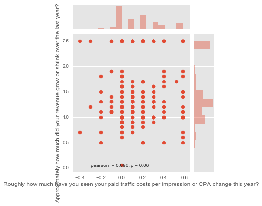

```python
sns.jointplot(data=modified_results[['Roughly how much have you seen your paid traffic costs per impression or CPA change this year?','Approximately how much did your revenue grow or shrink over the last year?']], x='Roughly how much have you seen your paid traffic costs per impression or CPA change this year?', y='Approximately how much did your revenue grow or shrink over the last year?')
```

#### Question: How does an owner's years of eCommerce experience correlate with their current business' annual revenues?

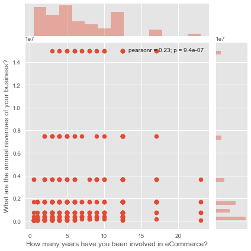

```python
sns.jointplot(data=modified_results, x='How many years have you been involved in eCommerce?', y='What are the annual revenues of your business?')
```

Looks like there is a mild correlation between years of experience and annual revenues, however after 4 years of experience, this difference becomes smaller

#### Question: Of stores where their website is their biggest channel, what is the difference in conversion rate between stores who have organic as their largest form of traffic vs PPC, email and the rest?

```python
modified_results[modified_results['What is your top sales channel?'] == 'My own website'].groupby('What is the biggest source of traffic to your website?').mean()['What is your average site-wide conversion rate?']
```

```
What is the biggest source of traffic to your website?
Direct                               0.041250
Email                                0.035938
Organic Search                       0.021656
Other                                0.017500
Paid Traffic                         0.024784
Referral (Links from Other Sites)    0.013500
Social (Non-Paid)                    0.019107
Name: What is your average site-wide conversion rate?, dtype: float64
```

#### Question: Let's take a look at Amazon-focused businesses vs non-Amazon businesses and compare them based on their growth rate, profit margins, PPC costs and optimism

```python
amazon_vs_rest = modified_results.copy()
amazon_vs_rest['amazon_focused'] = np.zeros(len(amazon_vs_rest))
for index in amazon_vs_rest.index.values:
    if amazon_vs_rest['What is your top sales channel?'][index] == 'Amazon':
        amazon_vs_rest['amazon_focused'][index] = 1
    elif amazon_vs_rest['What % of your sales come from Amazon?'][index] <= 0.3:
        amazon_vs_rest['amazon_focused'][index] = 2
```

```python
cols = [
    'Approximately how much did your revenue grow or shrink over the last year?',
    'What is your company’s approximate gross profit margin? (After paying product costs, but before fixed expenses.)',
    'What is your company\'s approximate net profit margin? (Profits after paying all expenses and salaries, including your salary).  ',
    'Roughly how much have you seen your paid traffic costs per impression or CPA change this year?',
    'How hopeful are you for the future prospects of your business?',
    'How much of an annual salary do you pay yourself?  (A regular, recurring salary -- not business withdrawls or dividends)',
    'What are the annual revenues of your business?'
]
amazon_vs_rest.groupby('amazon_focused')[cols].mean()
```

| amazon_focused | Approximately how much did your revenue grow or shrink over the last year? | What is your company’s approximate gross profit margin? (After paying product costs, but before fixed expenses.) | What is your company's approximate net profit margin? (Profits after paying all expenses and salaries, including your salary). | Roughly how much have you seen your paid traffic costs per impression or CPA change this year? | How hopeful are you for the future prospects of your business? | How much of an annual salary do you pay yourself? (A regular, recurring salary -- not business withdrawls or dividends) | What are the annual revenues of your business? |
| --- | --- | --- | --- | --- | --- | --- | --- |
| 0.0 | 1.588462 | 0.403846 | 0.176923 | 0.139000 | 7.769231 | 65288.461538 | 3.057692e+06 |
| 1.0 | 1.655462 | 0.368487 | 0.165336 | 0.165610 | 8.084034 | 62155.462185 | 2.611765e+06 |
| 2.0 | 1.378617 | 0.416801 | 0.174920 | 0.137931 | 8.266881 | 54556.270096 | 2.360048e+06 |

#### Question: Who has the hardest time maintaining their work:life balance? Let's compare our respondants based on their marital status

```python
modified_results.groupby('What\'s your marital status?')['How old are you?','How much do you struggle maintaining a work/life balance?','How many hours per week do you work?'].mean()
```

| What's your marital status? | How old are you? | How much do you struggle maintaining a work/life balance? | How many hours per week do you work? |
| --- | --- | --- | --- |
| Divorced | 46.807692 | 4.923077 | 43.192308 |
| Married | 40.256494 | 5.327922 | 46.613636 |
| Other | 34.868421 | 5.157895 | 36.473684 |
| Single | 32.814815 | 5.879630 | 48.013889 |
| Widowed | 59.125000 | 6.250000 | 40.500000 |

Looks like divorcees find their work:life balance the easiest compared to all other groups

#### Question: Let's take a look at ECF members. First off, are ECF members growing faster, are they happier, and are they more optimistic than non-members?

```python
modified_results.groupby('Are you a member of the eCommerceFuel Private Forum Community?').apply(np.mean).iloc[:,0:17]
```

| Are you a member of the eCommerceFuel Private Forum Community? | How many years have you been involved in eCommerce? | Excluding yourself, how many payrolled employees do you have? | How many contractors do you use in your business? | How many different SKUs do you sell? | How old are you? | How much do you struggle maintaining a work/life balance? | How many hours per week do you work? | Does your business provide a full-time income? Or, if you’re still working a job, could it? | What are the annual revenues of your business? | What is your average order value (AOV)? Please enter WITHOUT a "$" or currency sign. | Approximately how much did your revenue grow or shrink over the last year? | Approximately how much did your net income grow or shrink over the last year? | How much of an annual salary do you pay yourself? (A regular, recurring salary -- not business withdrawls or dividends) | What is your company’s approximate gross profit margin? (After paying product costs, but before fixed expenses.) | What is your company's approximate net profit margin? (Profits after paying all expenses and salaries, including your salary). | How much non-mortgage business related debt do you have? | How much cash in terms of your ongoing business expenses do you keep in your business? |
| --- | --- | --- | --- | --- | --- | --- | --- | --- | --- | --- | --- | --- | --- | --- | --- | --- | --- |
| 0.0 | 4.842262 | 3.327381 | 3.336310 | 2316.160714 | 38.675595 | 5.571429 | 46.520833 | 0.684524 | 1.487351e+06 | 503.232143 | 1.469345 | 1.411012 | 38494.047619 | 0.374554 | 0.183036 | 28020.833333 | 4.113095 |
| 1.0 | 7.508681 | 6.217014 | 4.032986 | 4279.010417 | 38.437500 | 5.388889 | 46.269097 | 0.902778 | 3.036111e+06 | 196.138889 | 1.459028 | 1.432118 | 68034.722222 | 0.420312 | 0.166406 | 57803.819444 | 5.881944 |

```python
modified_results.groupby('Are you a member of the eCommerceFuel Private Forum Community?').apply(np.mean).iloc[:,17:]
```

| Are you a member of the eCommerceFuel Private Forum Community? | What is your average site-wide conversion rate? | Apart from Amazon, do you use a 3PL or fulfillment company to fulfill your orders? | Do you use your home as your primary office / work space? | What % of your sales come from Amazon? | Roughly how much have you seen your paid traffic costs per impression or CPA change this year? | What is your net worth excluding your eCommerce business' value? (Net worth: Value of all your assets minus debts) | Approximately what % of your net worth (excluding business value) is invested in the stock market? | Approximately what % of your net worth (excluding business value) is in cash? | Approximately what % of your net worth (excluding business value) is invested in real estate? | How much do you enjoy running / owning your business? | How hopeful are you for the future prospects of your business? | How happy overall would you say you are in life? | Are you a member of the eCommerceFuel Private Forum Community? | How would you rate the eCommerceFuel Private Community? | Employee to Contractor Ratio |
| --- | --- | --- | --- | --- | --- | --- | --- | --- | --- | --- | --- | --- | --- | --- | --- |
| 0.0 | 0.026637 | 0.226190 | 0.636905 | 0.194792 | 0.165913 | 7.549107e+05 | 0.151786 | 0.252976 | 0.227679 | 8.196429 | 8.285714 | 7.922619 | 0.0 | NaN | 1.287528 |
| 1.0 | 0.026285 | 0.295139 | 0.461806 | 0.279340 | 0.133699 | 1.005266e+06 | 0.238889 | 0.239063 | 0.288021 | 8.145833 | 8.135417 | 8.059028 | 1.0 | 8.614583 | 2.607044 |

Here we see some key differences between groups: ECF members are 3 years more experienced, their stores earn twice as much, they pay themselves twice as much (and are much more likely to earn a full-time wage from their business) struggle less with work:life balance and are happier!

#### Now, let's look at some of the biggest struggles from all business

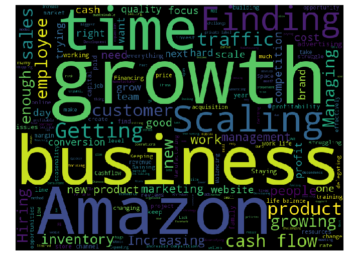

```python
from wordcloud import WordCloud
text = ' '.join(modified_results['What’s the biggest struggle you’re facing right now in your business?'].dropna())
wordcloud = WordCloud(width=800,height=600).generate(text)
plt.figure(figsize=(18,9))
plt.imshow(wordcloud)
plt.axis('off')
plt.savefig('wordcloud.png')
```

Here's our breakdown of happiness levels across respondents

```python
modified_results['How happy overall would you say you are in life?'].value_counts().sort_index()
```

```
3.0       2
4.0       9
5.0      21
6.0      24
7.0      98
8.0     127
9.0      91
10.0     84
Name: How happy overall would you say you are in life?, dtype: int64
```

```python
modified_results.groupby('Happiness level').mean().iloc[:,:17]
```

| Happiness level | How many years have you been involved in eCommerce? | Excluding yourself, how many payrolled employees do you have? | How many contractors do you use in your business? | How many different SKUs do you sell? | How old are you? | How much do you struggle maintaining a work/life balance? | How many hours per week do you work? | Does your business provide a full-time income? Or, if you’re still working a job, could it? | What are the annual revenues of your business? | What is your average order value (AOV)? Please enter WITHOUT a "$" or currency sign. | Approximately how much did your revenue grow or shrink over the last year? | Approximately how much did your net income grow or shrink over the last year? | How much of an annual salary do you pay yourself? (A regular, recurring salary -- not business withdrawls or dividends) | What is your company’s approximate gross profit margin? (After paying product costs, but before fixed expenses.) | What is your company's approximate net profit margin? (Profits after paying all expenses and salaries, including your salary). | How much non-mortgage business related debt do you have? | How much cash in terms of your ongoing business expenses do you keep in your business? |
| --- | --- | --- | --- | --- | --- | --- | --- | --- | --- | --- | --- | --- | --- | --- | --- | --- | --- |
| In the Middle (6-8) | 6.124498 | 5.024096 | 3.596386 | 3427.670683 | 38.234940 | 6.152610 | 47.433735 | 0.803213 | 2.404719e+06 | 218.506024 | 1.467671 | 1.415663 | 54769.076305 | 0.405723 | 0.170482 | 46957.831325 | 4.714859 |
| Unhappy (<= 5) | 6.171875 | 3.656250 | 4.234375 | 4072.968750 | 37.234375 | 6.656250 | 50.218750 | 0.687500 | 1.748438e+06 | 98.250000 | 1.362500 | 1.315625 | 38531.250000 | 0.414062 | 0.159375 | 48359.375000 | 4.015625 |
| Very Happy (9-10) | 7.162857 | 5.608571 | 3.948571 | 3643.685714 | 39.174286 | 4.245714 | 44.131429 | 0.874286 | 2.683143e+06 | 477.022857 | 1.474286 | 1.456571 | 63945.714286 | 0.398286 | 0.177857 | 46371.428571 | 6.185714 |

```python
modified_results.groupby('Happiness level').mean().iloc[:,17:]
```

| Happiness level | What is your average site-wide conversion rate? | Apart from Amazon, do you use a 3PL or fulfillment company to fulfill your orders? | Do you use your home as your primary office / work space? | What % of your sales come from Amazon? | Roughly how much have you seen your paid traffic costs per impression or CPA change this year? | What is your net worth excluding your eCommerce business' value? (Net worth: Value of all your assets minus debts) | Approximately what % of your net worth (excluding business value) is invested in the stock market? | Approximately what % of your net worth (excluding business value) is in cash? | Approximately what % of your net worth (excluding business value) is invested in real estate? | How much do you enjoy running / owning your business? | How hopeful are you for the future prospects of your business? | How happy overall would you say you are in life? | Are you a member of the eCommerceFuel Private Forum Community? | How would you rate the eCommerceFuel Private Community? | Employee to Contractor Ratio |
| --- | --- | --- | --- | --- | --- | --- | --- | --- | --- | --- | --- | --- | --- | --- | --- |
| In the Middle (6-8) | 0.026446 | 0.277108 | 0.546185 | 0.262249 | 0.151823 | 8.136707e+05 | 0.207831 | 0.248394 | 0.261647 | 7.847390 | 7.951807 | 7.413655 | 0.634538 | 8.531646 | 2.300421 |
| Unhappy (<= 5) | 0.025234 | 0.375000 | 0.687500 | 0.267187 | 0.154444 | 8.256562e+05 | 0.217187 | 0.292187 | 0.221875 | 6.843750 | 7.000000 | 4.593750 | 0.593750 | 7.947368 | 1.319196 |
| Very Happy (9-10) | 0.026586 | 0.240000 | 0.468571 | 0.224714 | 0.134074 | 1.070380e+06 | 0.203429 | 0.229429 | 0.279714 | 8.857143 | 8.748571 | 9.480000 | 0.634286 | 8.846847 | 2.012082 |

Takeaways:

- Happiness levels tend to be correlated with your age/eCommerce experience as well as how well your business is doing (business revenue & growth), although this probably has more to do with the fact that older/more experienced respondents have more successful businesses.
- Those who are most unhappy tend to work more, struggle most with work:life balance (plus work from home more often), are less likely to earn a full-time income from their business (and less income from it overall), and are less hopeful for their business' future prospects.
- Interestingly, net worth was similar between the unhappy group and those in the middle, despite the large differences in income (with no statistical correlation - shown below) and many of the other factors.

As shown below, these differences are not explained for by store type either, with a fairly even happiness distribution across each model.

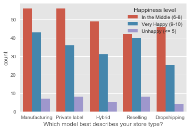

```python
sns.countplot(data=modified_results, hue='Happiness level', x='Which model best describes your store type?', order=order)
plt.savefig('store_by_happiness.png')
```

```python
print('Correlation between Happiness and net worth: ' + str(modified_results['How happy overall would you say you are in life?'].corr(modified_results['What is your net worth excluding your eCommerce business\' value? (Net worth:  Value of all your assets minus debts)'])))
```

```
Correlation between Happiness and net worth: 0.0869324426966
```

### Is there a correlation between high-growth businesses and whether they hire contractors or employees more often?

```python
modified_results['Approximately how much did your revenue grow or shrink over the last year?'].corr(modified_results['Employee to Contractor Ratio'])
```

```
-0.046876377791883958
```

```python
modified_results['Total staff'] = modified_results['Excluding yourself, how many payrolled employees do you have?'] + modified_results['How many contractors do you use in your business?']
```

```python
from sklearn.preprocessing import StandardScaler
scaler = StandardScaler()
scaler.fit(modified_results[numeric_features])
scaled_numeric_features = pd.DataFrame(scaler.transform(modified_results[numeric_features]), columns=modified_results[numeric_features].columns)
scaled_numeric_features.head()
```

|  | How many years have you been involved in eCommerce? | Excluding yourself, how many payrolled employees do you have? | How many contractors do you use in your business? | How many different SKUs do you sell? | How old are you? | How much do you struggle maintaining a work/life balance? | How many hours per week do you work? | Does your business provide a full-time income? Or, if you’re still working a job, could it? | What are the annual revenues of your business? | What is your average order value (AOV)? Please enter WITHOUT a "$" or currency sign. | ... | Do you use your home as your primary office / work space? | What % of your sales come from Amazon? | What is your net worth excluding your eCommerce business' value? (Net worth: Value of all your assets minus debts) | Approximately what % of your net worth (excluding business value) is invested in the stock market? | Approximately what % of your net worth (excluding business value) is in cash? | Approximately what % of your net worth (excluding business value) is invested in real estate? | How much do you enjoy running / owning your business? | How hopeful are you for the future prospects of your business? | How happy overall would you say you are in life? | Employee to Contractor Ratio |
| --- | --- | --- | --- | --- | --- | --- | --- | --- | --- | --- | --- | --- | --- | --- | --- | --- | --- | --- | --- | --- | --- |
| 0 | -0.722479 | 0.241744 | 2.296092 | -0.429275 | -1.464282 | 0.966785 | 0.526962 | 0.464758 | 1.326095 | -0.117323 | ... | -1.054093 | -0.748404 | -0.089358 | 0.756665 | 1.377325 | -0.937317 | -0.102739 | 0.433302 | -0.679855 | -0.411634 |
| 1 | 0.711695 | 3.251135 | -0.062057 | -0.067199 | -0.405781 | 0.966785 | -0.049699 | 0.464758 | 3.301612 | -0.096319 | ... | -1.054093 | -0.446860 | 1.691999 | -0.809915 | 1.377325 | 0.473299 | -0.102739 | 0.433302 | 0.668031 | 1.638128 |
| 2 | 1.223900 | -0.543314 | -0.062057 | -0.067199 | 0.602316 | 1.726878 | 2.285777 | 0.464758 | -0.201639 | -0.103040 | ... | 0.948683 | -0.145316 | -0.404521 | -0.809915 | -0.558145 | -0.937317 | -0.727390 | 0.968764 | -3.375627 | -0.466052 |
| 3 | -0.517597 | 0.241744 | -0.062057 | -0.384544 | -1.464282 | 0.206692 | -0.626360 | 0.464758 | 0.325166 | -0.094218 | ... | -1.054093 | 1.663948 | -0.404521 | -0.418270 | 1.764419 | -0.937317 | 0.521912 | 0.433302 | -0.005912 | -0.030705 |
| 4 | -0.927361 | -0.543314 | -0.062057 | -0.067199 | -1.464282 | 1.346831 | -0.626360 | 0.464758 | -0.201639 | -0.094218 | ... | 0.948683 | -0.748404 | -0.466458 | 1.148311 | 0.990231 | -0.937317 | -1.352041 | -0.637623 | -1.353798 | -0.466052 |

5 rows × 29 columns